# Halloween MiniProject

Diana Furlan

2024-10-28

```r
url <- "https://raw.githubusercontent.com/fivethirtyeight/data/master/candy-power-ranking/candy-data.csv"

candy_file <- read.csv(url)
candy = read.csv(url, row.names=1)
head(candy)
```

```
##              chocolate fruity caramel peanutyalmondy nougat crispedricewafer
## 100 Grand            1      0       1              0      0                1
## 3 Musketeers         1      0       0              0      1                0
## One dime             0      0       0              0      0                0
## One quarter          0      0       0              0      0                0
## Air Heads            0      1       0              0      0                0
## Almond Joy           1      0       0              1      0                0
##              hard bar pluribus sugarpercent pricepercent winpercent
## 100 Grand       0   1        0        0.732        0.860   66.97173
## 3 Musketeers    0   1        0        0.604        0.511   67.60294
## One dime        0   0        0        0.011        0.116   32.26109
## One quarter     0   0        0        0.011        0.511   46.11650
## Air Heads       0   0        0        0.906        0.511   52.34146
## Almond Joy      0   1        0        0.465        0.767   50.34755
```

> Q1. How many different candy types are in this dataset?

```r
candies <- nrow(candy)
candies
```

```
## [1] 85
```

> Q2. How many fruity candy types are in the dataset?

```r
fruity <- sum(candy$fruity == 1)
fruity
```

```
## [1] 38
```

> Q3. What is your favorite candy in the dataset and what is it’s winpercent value?

```r
candy["Almond Joy", ]$winpercent
```

```
## [1] 50.34755
```

> Q4. What is the winpercent value for “Kit Kat”?

```r
candy["Kit Kat", ]$winpercent
```

```
## [1] 76.7686
```

> Q5. What is the winpercent value for “Tootsie Roll Snack Bars”?

```r
candy["Tootsie Roll Snack Bars", ]$winpercent
```

```
## [1] 49.6535
```

There is a useful’skim()’function in the skimr package that can help give you a quick overview of a given dataset

```r
#install.packages("skimr")
library("skimr")
#or just extract a part from the library
#skimr::skim(candy)
skim(candy)
```

Data summary

| Name | candy |
| --- | --- |
| Number of rows | 85 |
| Number of columns | 12 |
| _______________________ |  |
| Column type frequency: |  |
| numeric | 12 |
| ________________________ |  |
| Group variables | None |

**Variable type: numeric**

| skim_variable | n_missing | complete_rate | mean | sd | p0 | p25 | p50 | p75 | p100 | hist |
| --- | --- | --- | --- | --- | --- | --- | --- | --- | --- | --- |
| chocolate | 0 | 1 | 0.44 | 0.50 | 0.00 | 0.00 | 0.00 | 1.00 | 1.00 | ▇▁▁▁▆ |
| fruity | 0 | 1 | 0.45 | 0.50 | 0.00 | 0.00 | 0.00 | 1.00 | 1.00 | ▇▁▁▁▆ |
| caramel | 0 | 1 | 0.16 | 0.37 | 0.00 | 0.00 | 0.00 | 0.00 | 1.00 | ▇▁▁▁▂ |
| peanutyalmondy | 0 | 1 | 0.16 | 0.37 | 0.00 | 0.00 | 0.00 | 0.00 | 1.00 | ▇▁▁▁▂ |
| nougat | 0 | 1 | 0.08 | 0.28 | 0.00 | 0.00 | 0.00 | 0.00 | 1.00 | ▇▁▁▁▁ |
| crispedricewafer | 0 | 1 | 0.08 | 0.28 | 0.00 | 0.00 | 0.00 | 0.00 | 1.00 | ▇▁▁▁▁ |
| hard | 0 | 1 | 0.18 | 0.38 | 0.00 | 0.00 | 0.00 | 0.00 | 1.00 | ▇▁▁▁▂ |
| bar | 0 | 1 | 0.25 | 0.43 | 0.00 | 0.00 | 0.00 | 0.00 | 1.00 | ▇▁▁▁▂ |
| pluribus | 0 | 1 | 0.52 | 0.50 | 0.00 | 0.00 | 1.00 | 1.00 | 1.00 | ▇▁▁▁▇ |
| sugarpercent | 0 | 1 | 0.48 | 0.28 | 0.01 | 0.22 | 0.47 | 0.73 | 0.99 | ▇▇▇▇▆ |
| pricepercent | 0 | 1 | 0.47 | 0.29 | 0.01 | 0.26 | 0.47 | 0.65 | 0.98 | ▇▇▇▇▆ |
| winpercent | 0 | 1 | 50.32 | 14.71 | 22.45 | 39.14 | 47.83 | 59.86 | 84.18 | ▃▇▆▅▂ |

> Q6. Is there any variable/column that looks to be on a different scale to the majority of the other columns in the dataset? sugarpercent, pricepercent and winpercent are on a non binary scale.

> Q7. What do you think a zero and one represent for the candy$chocolate column? 1 = T for chocolate and 0 = F for chocolate

> Q8. Plot a histogram of winpercent values

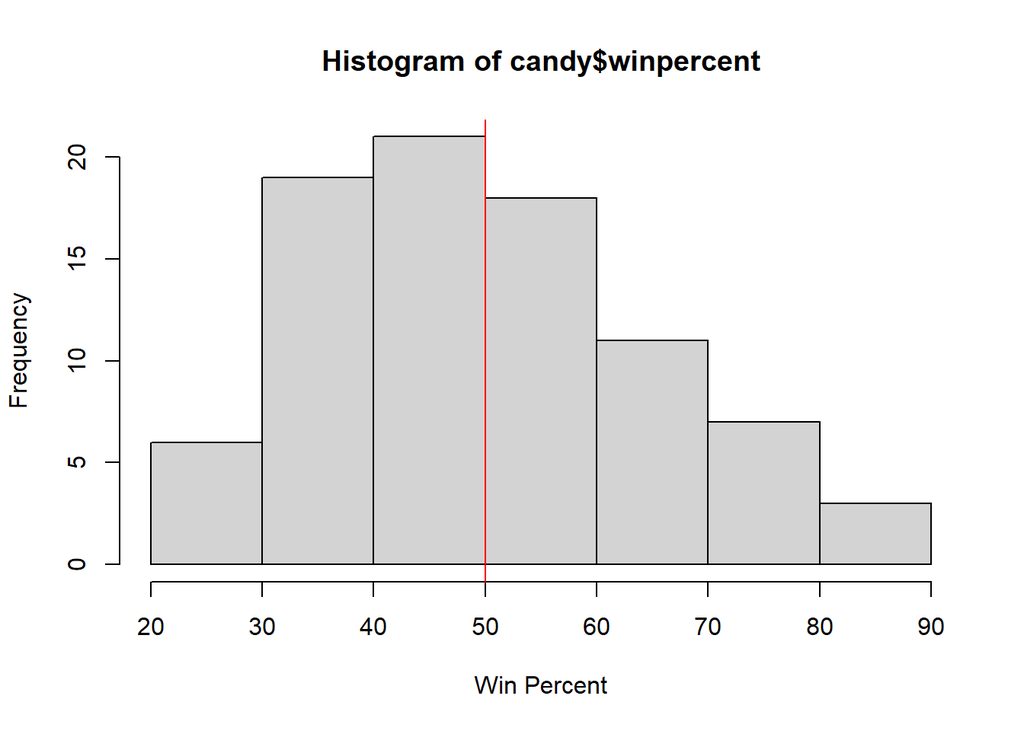

```r
#can add color with 'col'- how to change the title?

hist(candy$winpercent, xlab = "Win Percent")
  abline(v = 50, col = "red")
```

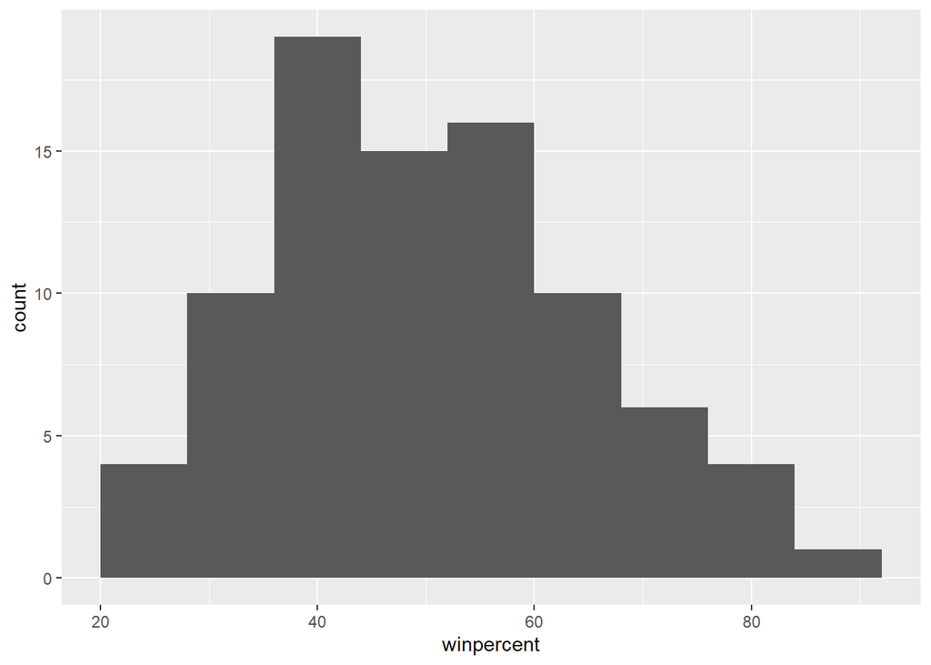

```r
library(ggplot2)

ggplot(candy) +
  aes(winpercent) +
  geom_histogram(binwidth = 8)
```

> Q9. Is the distribution of winpercent values symmetrical? slighly right-skewed

```r
summary(candy$winpercent)
```

```
##    Min. 1st Qu.  Median    Mean 3rd Qu.    Max.
##   22.45   39.14   47.83   50.32   59.86   84.18
```

> Q11. On average is chocolate candy higher or lower ranked than fruit candy? chocolate seems higher

```r
summary(candy[as.logical(candy$chocolate),]$winpercent)
```

```
##    Min. 1st Qu.  Median    Mean 3rd Qu.    Max.
##   34.72   50.35   60.80   60.92   70.74   84.18
```

```r
#installed.packages("dplyr")
```

```r
library(dplyr)
fruit.candy <- candy |>
   filter(fruity==1)

summary(fruit.candy$winpercent)
```

```
##    Min. 1st Qu.  Median    Mean 3rd Qu.    Max.
##   22.45   39.04   42.97   44.12   52.11   67.04
```

> Q12. Is this difference statistically significant?

```r
choc.candy <- candy |> filter(chocolate ==1)
fruit.candy <- candy |> filter(fruity == 1)
```

```r
t_test_result <- t.test(choc.candy$winpercent, fruit.candy$winpercent)

t_test_result
```

```
##
##  Welch Two Sample t-test
##
## data:  choc.candy$winpercent and fruit.candy$winpercent
## t = 6.2582, df = 68.882, p-value = 2.871e-08
## alternative hypothesis: true difference in means is not equal to 0
## 95 percent confidence interval:
##  11.44563 22.15795
## sample estimates:
## mean of x mean of y
##  60.92153  44.11974
```

```r
play <- c("d","a","c")
sort(play)
```

```
## [1] "a" "c" "d"
```

```r
order(play)
```

```
## [1] 2 3 1
```

```r
play[order(play) ]
```

```
## [1] "a" "c" "d"
```

> Q13. What are the five least liked candy types in this set?

```r
sort(c(5, 2, 10), decreasing = T)
```

```
## [1] 10  5  2
```

```r
head( candy[order(candy$winpercent),], 5)
```

```
##                    chocolate fruity caramel peanutyalmondy nougat
## Nik L Nip                  0      1       0              0      0
## Boston Baked Beans         0      0       0              1      0
## Chiclets                   0      1       0              0      0
## Super Bubble               0      1       0              0      0
## Jawbusters                 0      1       0              0      0
##                    crispedricewafer hard bar pluribus sugarpercent pricepercent
## Nik L Nip                         0    0   0        1        0.197        0.976
## Boston Baked Beans                0    0   0        1        0.313        0.511
## Chiclets                          0    0   0        1        0.046        0.325
## Super Bubble                      0    0   0        0        0.162        0.116
## Jawbusters                        0    1   0        1        0.093        0.511
##                    winpercent
## Nik L Nip            22.44534
## Boston Baked Beans   23.41782
## Chiclets             24.52499
## Super Bubble         27.30386
## Jawbusters           28.12744
```

> Q14. What are the top 5 all time favorite candy types out of this set?

```r
#candy%>%
 # arrange(winpercent) %>% head(5)
```

> Q15. Make a first barplot of candy ranking based on winpercent values.

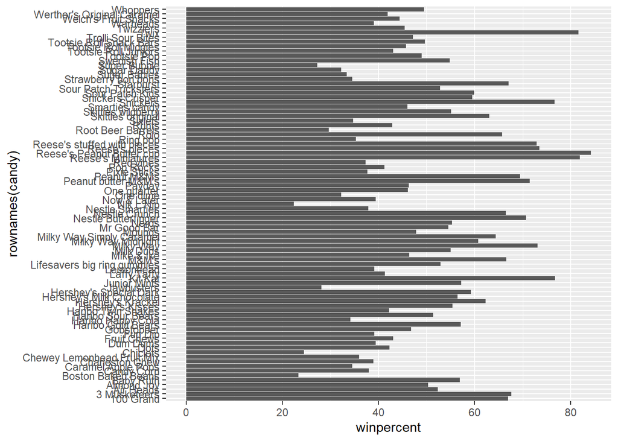

```r
library(ggplot2)

ggplot(candy) +
  aes(winpercent, rownames(candy)) +
  geom_col()
```

> Q16. This is quite ugly, use the reorder() function to get the bars sorted by winpercent?

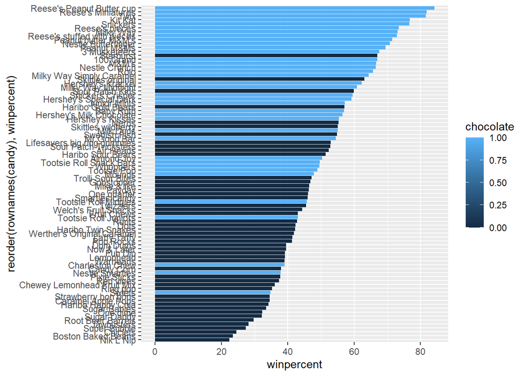

```r
ggplot(candy) +
  aes(x=winpercent,
      y=reorder(rownames(candy), winpercent),
      fill= chocolate) +
  geom_col()
```

More custom col skim so we can see both chocolate and bar and fruity, etc. all from the same plot

```r
mycols <- rep("black", nrow(candy))
mycols[as.logical(candy$chocolate)] <- "chocolate"
mycols [as.logical(candy$bar)] <- "brown"
mycols [as.logical(candy$fruity)] <- "pink"
#use blue for my fav candy
```

```r
mycols [rownames(candy)=="Almond Joy"] <- "blue"
mycols
```

```
##  [1] "brown"     "brown"     "black"     "black"     "pink"      "blue"
##  [7] "brown"     "black"     "black"     "pink"      "brown"     "pink"
## [13] "pink"      "pink"      "pink"      "pink"      "pink"      "pink"
## [19] "pink"      "black"     "pink"      "pink"      "chocolate" "brown"
## [25] "brown"     "brown"     "pink"      "chocolate" "brown"     "pink"
## [31] "pink"      "pink"      "chocolate" "chocolate" "pink"      "chocolate"
## [37] "brown"     "brown"     "brown"     "brown"     "brown"     "pink"
## [43] "brown"     "brown"     "pink"      "pink"      "brown"     "chocolate"
## [49] "black"     "pink"      "pink"      "chocolate" "chocolate" "chocolate"
## [55] "chocolate" "pink"      "chocolate" "black"     "pink"      "chocolate"
## [61] "pink"      "pink"      "chocolate" "pink"      "brown"     "brown"
## [67] "pink"      "pink"      "pink"      "pink"      "black"     "black"
## [73] "pink"      "pink"      "pink"      "chocolate" "chocolate" "brown"
## [79] "pink"      "brown"     "pink"      "pink"      "pink"      "black"
## [85] "chocolate"
```

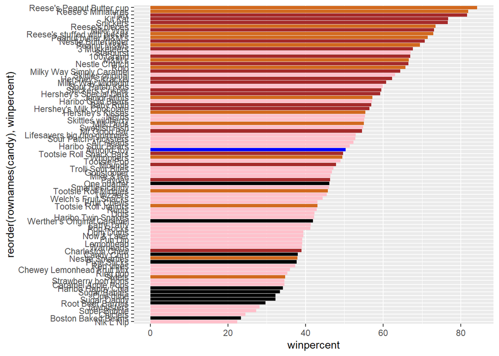

```r
#placeholder
ggplot(candy) +
  aes(x=winpercent,
      y=reorder(rownames(candy), winpercent),) +
  geom_col(fill =mycols)
```

> Q18. What is the best ranked fruity candy? Starbust

```r
mycols[as.logical(candy$fruity)]<- "red"
mycols
```

```
##  [1] "brown"     "brown"     "black"     "black"     "red"       "blue"
##  [7] "brown"     "black"     "black"     "red"       "brown"     "red"
## [13] "red"       "red"       "red"       "red"       "red"       "red"
## [19] "red"       "black"     "red"       "red"       "chocolate" "brown"
## [25] "brown"     "brown"     "red"       "chocolate" "brown"     "red"
## [31] "red"       "red"       "chocolate" "chocolate" "red"       "chocolate"
## [37] "brown"     "brown"     "brown"     "brown"     "brown"     "red"
## [43] "brown"     "brown"     "red"       "red"       "brown"     "chocolate"
## [49] "black"     "red"       "red"       "chocolate" "chocolate" "chocolate"
## [55] "chocolate" "red"       "chocolate" "black"     "red"       "chocolate"
## [61] "red"       "red"       "chocolate" "red"       "brown"     "brown"
## [67] "red"       "red"       "red"       "red"       "black"     "black"
## [73] "red"       "red"       "red"       "chocolate" "chocolate" "brown"
## [79] "red"       "brown"     "red"       "red"       "red"       "black"
## [85] "chocolate"
```

```r
#install.packages("ggrepel")
```

```r
#library(ggrepel)
#ggplot (candy) +
 # aes(winpercent,pricepercent, label=rownames(candy)) +
  #geom_point(col=mycols) +
  #geom_label(col=mycols) +
  #geom_text_repel(max.overlaps = 8, col=mycols, )
```

> Q19. Which candy type is the highest ranked in terms of winpercent for the least money - i.e. offers the most bang for your buck?

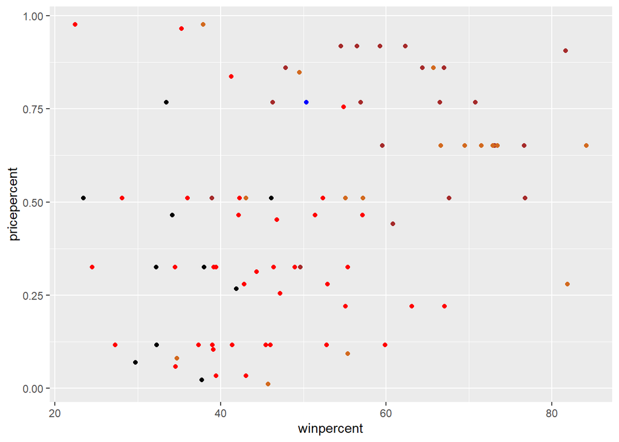

```r
ggplot (candy)+
  aes(winpercent,pricepercent)+
  geom_point(col=mycols)
```

> Q20. What are the top 5 most expensive candy types in the dataset and of these which is the least popular?

```r
ord <- order(candy$pricepercent, decreasing = TRUE)
head ( candy[ ord, c(11,12)], n=5 )
```

```
##                          pricepercent winpercent
## Nik L Nip                       0.976   22.44534
## Nestle Smarties                 0.976   37.88719
## Ring pop                        0.965   35.29076
## Hershey's Krackel               0.918   62.28448
## Hershey's Milk Chocolate        0.918   56.49050
```

```r
#install.packages("corrplot")
```

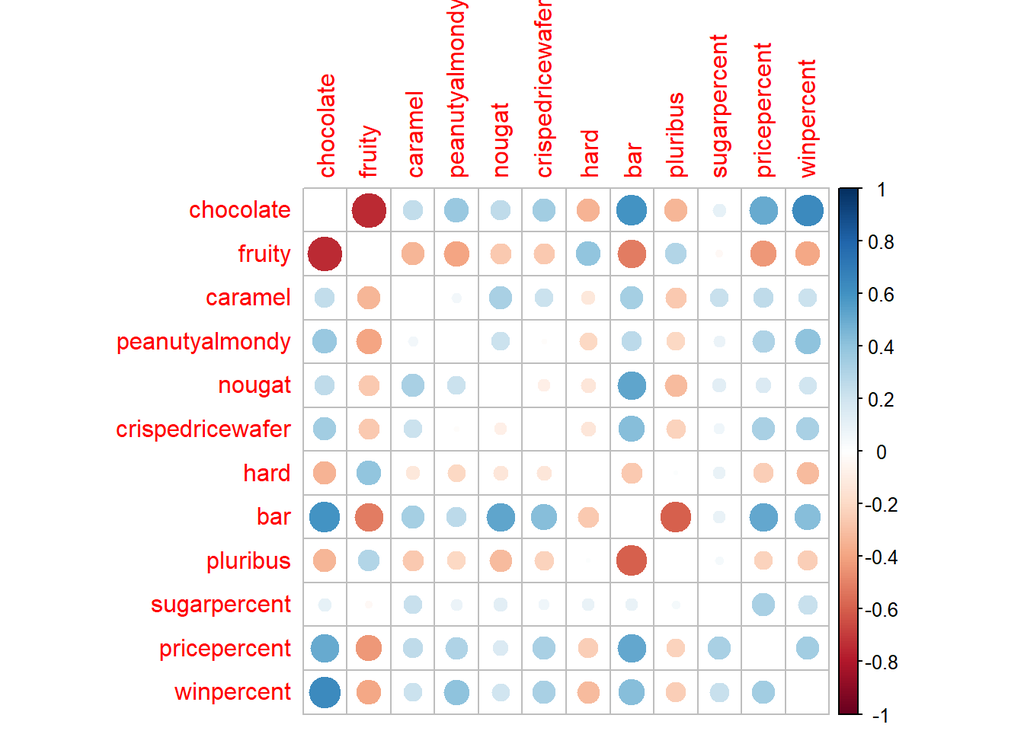

```r
library(corrplot)
cij <- cor(candy)
corrplot (cij, diag=F)
```

>Q22. Examining this plot what two variables are anti-correlated (i.e. have minus values)? chocolate and gruit

```r
pca <- prcomp(candy, scale= T)
summary(pca)
```

```
## Importance of components:
##                           PC1    PC2    PC3     PC4    PC5     PC6     PC7
## Standard deviation     2.0788 1.1378 1.1092 1.07533 0.9518 0.81923 0.81530
## Proportion of Variance 0.3601 0.1079 0.1025 0.09636 0.0755 0.05593 0.05539
## Cumulative Proportion  0.3601 0.4680 0.5705 0.66688 0.7424 0.79830 0.85369
##                            PC8     PC9    PC10    PC11    PC12
## Standard deviation     0.74530 0.67824 0.62349 0.43974 0.39760
## Proportion of Variance 0.04629 0.03833 0.03239 0.01611 0.01317
## Cumulative Proportion  0.89998 0.93832 0.97071 0.98683 1.00000
```

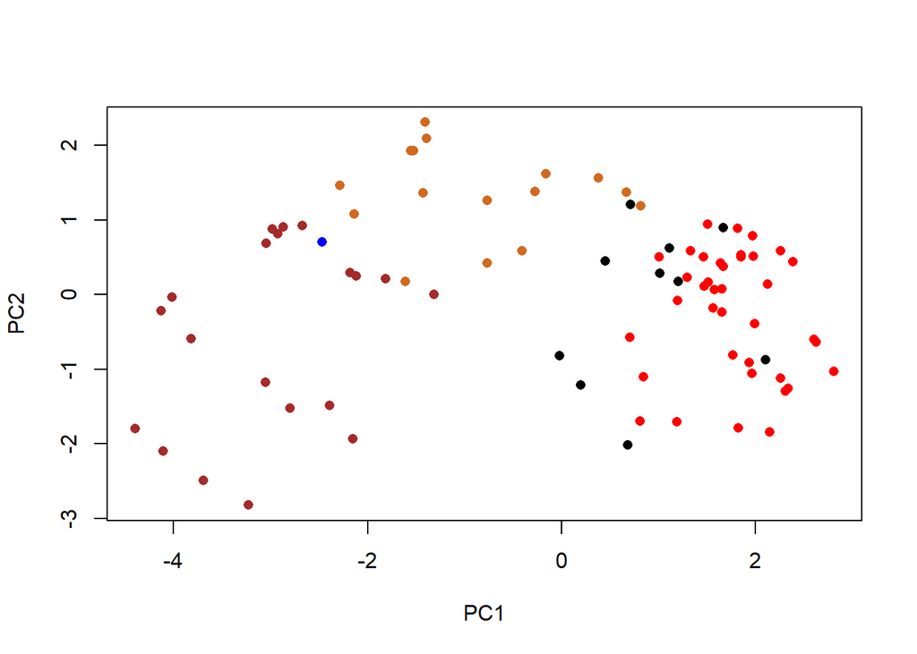

```r
plot(pca$x[,1], pca$x[,2], col=mycols, pch=16, xlab = "PC1", ylab = "PC2")
```

how do the original variables cols contribute to the new pca. PC1:

```r
loadings <- cbind(candy, pca$x[,1:3])
```

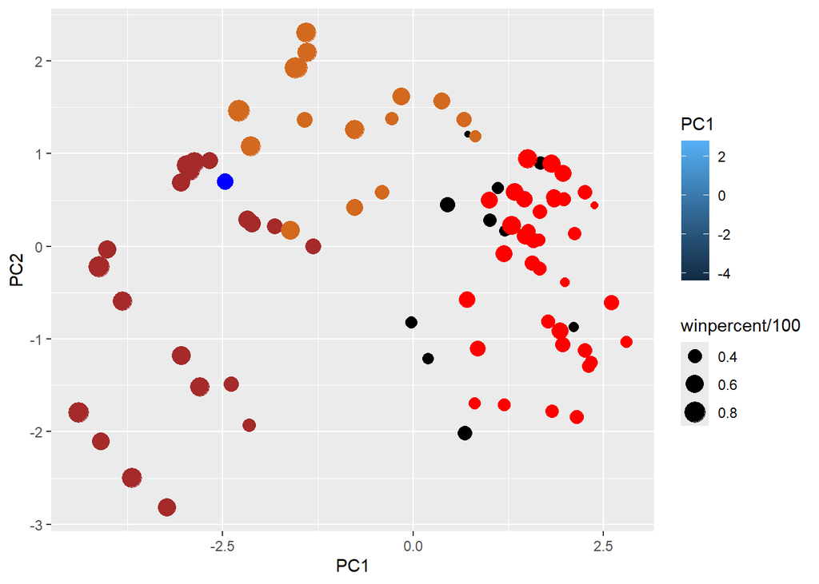

```r
p <- ggplot(loadings) +
  aes(x= PC1, y= PC2,
      text=rownames(loadings), fill = PC1, size= winpercent/100) +
  geom_point(col=mycols)

  p
```

```r
#install.packages("ggrepel")
#library(ggrepel)

#q <- ggplot(loadings) +
 # aes(x = PC1, y = PC2, text = rownames(loadings), fill = PC1, size = winpercent / 100) +
  #geom_point(col=mycols) +
  #geom_text_repel(aes(label = rownames(loadings)), size = 3.3, col = mycols, max.overlaps = 8) +
  #theme(legend.position = "none") +
  #labs(title = "Halloween Candy PCA Space", subtitle = "Colored by type: chocolate bar (dark brown), chocolate other (light brown), fruity (red), other (black)",
   # caption = "Data from 538")
#q
```

```r
#install.packages("plotly")
#library(plotly)

#ggplotly(q)
```

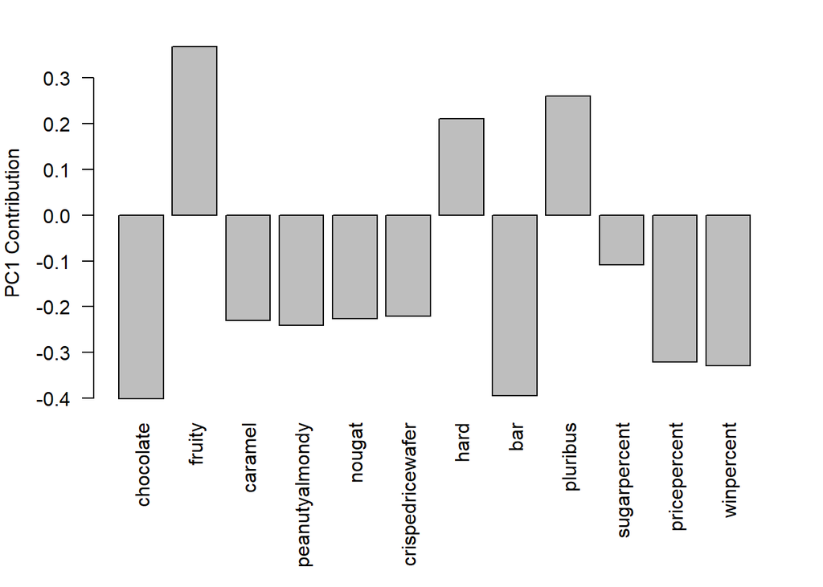

```r
par(mar=c(8,4,2,2))
barplot(pca$rotation[,1], las=2, ylab="PC1 Contribution")
```

> Q24. What original variables are picked up strongly by PC1 in the positive direction? Do these make sense to you?No,I think it should be reveresed